# Probability and Statistics

# Lab Assignment 1: Naive Bayes Classifier

## Work breakdown

- *Gordiy Eliseev*: Data pre-processing, Data visualization
- *Mykyta Yagoda*: Classifier implementation
- *Vladyslav Shymanovskyi*: Measurements of effectiveness of your classifier, Conclusions

## Introduction

During the first three weeks, you learned a couple of essential notions and theorems, and one of the most important among them is the **Bayes theorem**.

**Naive Bayes Classifier** is a simple algorithm, which is based on **Bayes theorem** and used for solving classification problems. **Classification problem** is a problem in which an observation has to be classified in one of the $n$ classes based on its similarity with observations in each class.

It is a **probabilistic classifier**, which means it predicts based on the probability of an observation belonging to each class. To compute it, this algorithm uses **Bayes’ formula,** that you probably already came across in **Lesson 3:**
$$\mathsf{P}(\mathrm{class}\mid
\mathrm{observation})=\frac{\mathsf{P}(\mathrm{observation}\mid\mathrm{class})\mathsf{P}(\mathrm{class})}{\mathsf{P}(\mathrm{observation})}$$

Under the strong **independence** assumption, one can calculate $\mathsf{P}(\mathrm{observation} \mid \mathrm{class})$ as
$$\mathsf{P}(\mathrm{observation}) =
\prod_{i=1}^{n} \mathsf{P}(\mathrm{feature}_i), \qquad
\mathsf{P}(\mathrm{observation} \mid \mathrm{class}) = \prod_{i=1}^{n}
\mathsf{P}(\mathrm{feature}_i \mid \mathrm{class}),$$
where $n$ is the total number of features describing a given observation (*For example, if an observation is presented as a sentence, then each word can be a feature*). Thus, $\mathsf{P}(\mathrm{class}|\mathrm{observation})$ now can be calculated as

$$\mathsf{P}(\mathrm{class} \mid
\mathrm{\mathrm{observation}}) = \mathsf{P}(\mathrm{class})\times
\prod_{i=1}^{n}\frac{\mathsf{P}(\mathrm{feature}_i\mid
\mathrm{class})}{\mathsf{P}(\mathrm{feature}_i)}\tag{1}$$

All the terms on the right-hand side can be estimated as corresponding relative frequencies using available data

**See [*this link*](https://www.javatpoint.com/machine-learning-naive-bayes-classifier) for more detailed explanations & examples :) Also you can watch [*this video*](https://youtu.be/O2L2Uv9pdDA?si=-ohkHVDuu3sLLGMq) for more examples!**

## Data description

There are 5 datasets uploaded on the cms (data.zip)

To determine your variant, take your team number from the list of teams on cms and take *mod 5* - this is the number of your data set.

- **0 - authors** This data set consists of citations of three famous writers: Edgar Alan Poe, Mary Wollstonecraft Shelley and HP Lovecraft. The task with this data set is to classify a piece of text with the author who was more likely to write it.
- **1 - discrimination** This data set consists of tweets that have discriminatory (sexism or racism) messages or of tweets that are of neutral mood. The task is to determine whether a given tweet has discriminatory mood or does not.
- **2 - fake news** This data set contains data of American news: a headline and an abstract of the article. Each piece of news is classified as fake or credible. The task is to classify the news from test.csv as credible or fake.
- **3 - sentiment** All the text messages contained in this data set are labeled with three sentiments: positive, neutral or negative. The task is to classify some text message as the one of positive mood, negative or neutral.
- **4 - spam** This last data set contains SMS messages classified as spam or non-spam (ham in the data set). The task is to determine whether a given message is spam or non-spam.

Each data set consists of two files: *train.csv* and *test.csv*. The first one is used to find the probabilities of the corresponding classes and the second one is used to test your classifier afterwards. Note that it is crucial to randomly split your data into training and testing parts to test the classifierʼs possibilities on the unseen data.

```r
# here goes a list of recommended libraries,
# though you may install other ones if they are needed

options(repos = c(CRAN = "https://cloud.r-project.org"))

if (!require("pacman")) install.packages("pacman")
pacman::p_load(
  dplyr,
  ggplot2,
  tidytext,
  readr,
  patchwork,
  wordcloud
)
```

## Outline of the work

1. **Data pre-processing** (includes removing punctuation marks and stop words, representing each message as a bag-of-words)
2. **Data visualization** (it’s time to plot your data!)
3. **Classifier implementation** (using the training set, calculate all the conditional probabilities in formula (1))
4. **Measurements of effectiveness of your classifier** (use the results from the previous step to predict classes for messages in the testing set and measure the accuracy, precision and recall, F1 score metric etc)
5. **Conclusions**

*!! do not forget to submit both the (compiled) Rmd source file and the .html output !!*

## Data pre-processing

- Read the *.csv* data files.
- Сlear your data from punctuation or other unneeded symbols.
- Clear you data from stop words. You don’t want words as is, and, or etc. to affect your probabilities distributions, so it is a wise decision to get rid of them. Find list of stop words in the cms under the lab task.
- Represent each test message as its bag-of-words. Here: https://machinelearningmastery.com/gentle-introduction-bag-words-model/ you can find general introduction to the bag-of-words model and examples on to create it.
- It is highly recommended to get familiar with R dataframes, it would make the work much easier to do.
- Useful links:
  - https://steviep42.github.io/webscraping/book/bagofwords.html#tidytext - example of using *tidytext* to count frequencies of the words.
  - Basics of Text Mining in R: http://rstudio-pubs-static.s3.amazonaws.com/256588_57b585da6c054349825cba46685d8464.html . Note that it also includes an example on how to create a bag of words from your text document.

```r
list.files(getwd())
```

```
## [1] "data"
## [2] "Lab1_Naive_Bayes_Classifier_Templatee-4.html"
## [3] "Lab1_Naive_Bayes_Classifier_Templatee-4.Rmd"
## [4] "stop_words.txt"
```

```r
list.files("data/0-authors")
```

```
## [1] "test.csv"  "train.csv"
```

```r
test_path <- "data/0-authors/test.csv"
train_path <- "data/0-authors/train.csv"

stop_words <- read_file("stop_words.txt")
splitted_stop_words <- strsplit(stop_words, "\n") %>%
  unlist() %>%
  gsub("\r", "", .) %>%
  unique()

splitted_stop_words
```

```
##   [1] "a"               "about"           "above"           "after"
##   [5] "again"           "against"         "all"             "am"
##   [9] "an"              "and"             "any"             "are"
##  [13] "aren't"          "as"              "at"              "be"
##  [17] "because"         "been"            "before"          "being"
##  [21] "below"           "between"         "both"            "but"
##  [25] "by"              "can't"           "cannot"          "could"
##  [29] "couldn't"        "did"             "didn't"          "do"
##  [33] "does"            "doesn't"         "doing"           "don't"
##  [37] "down"            "during"          "each"            "few"
##  [41] "for"             "from"            "further"         "had"
##  [45] "hadn't"          "has"             "hasn't"          "have"
##  [49] "haven't"         "having"          "he"              "he'd"
##  [53] "he'll"           "he's"            "her"             "here"
##  [57] "here's"          "hers"            "herself"         "him"
```

[output cut: 29 more lines]

```r
train <-  read.csv(file = train_path, stringsAsFactors = FALSE, row.names = 1)
test <-  read.csv(file = test_path, stringsAsFactors = FALSE, row.names = 1)
```

```r
# note the power functional features of R bring us!
tidy_text_train <- unnest_tokens(train, 'splitted', 'text', token="words") %>%
             filter(!splitted %in% splitted_stop_words)

tidy_text_test <- unnest_tokens(test, 'splitted', 'text', token="words") %>%
             filter(!splitted %in% splitted_stop_words)

t_counts <- tidy_text_train %>% count(splitted,sort=TRUE)
tidy_text_train
```

```
##            id                       author          splitted
## 1     id12391                 HP Lovecraft            palace
## 2     id12391                 HP Lovecraft              also
## 3     id12391                 HP Lovecraft              many
## 4     id12391                 HP Lovecraft         galleries
## 5     id12391                 HP Lovecraft              many
## 6     id12391                 HP Lovecraft     amphitheatres
## 7     id12391                 HP Lovecraft             lions
## 8     id12391                 HP Lovecraft               men
## 9     id12391                 HP Lovecraft         elephants
## 10    id12391                 HP Lovecraft           battled
## 11    id12391                 HP Lovecraft          pleasure
## 12    id12391                 HP Lovecraft             kings
## 13    id08596                 HP Lovecraft               now
## 14    id08596                 HP Lovecraft              bent
```

[output cut: 33320 more lines]

## Data visualization

Each time you work with some data, you need to understand it before you start processing it. R has very powerful tools to make nice plots and visualization. Show what are the most common words for negative and positive examples as a histogram, word cloud etc. Be creative!

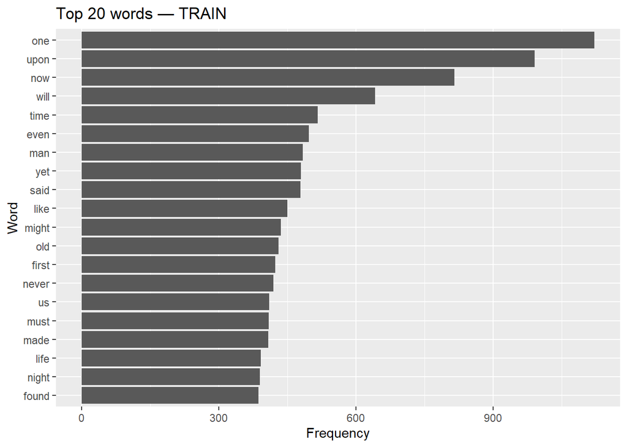

```r
t_counts_train <- tidy_text_train %>% count(splitted, sort = TRUE, name = "freq")
t_counts_test  <- tidy_text_test  %>% count(splitted, sort = TRUE, name = "freq")

# Top-20 barplot (train)
ggplot(t_counts_train %>% slice_max(freq, n = 20),
       aes(x = reorder(splitted, freq), y = freq)) +
  geom_col() +
  coord_flip() +
  labs(title = "Top 20 words — TRAIN", x = "Word", y = "Frequency")
```

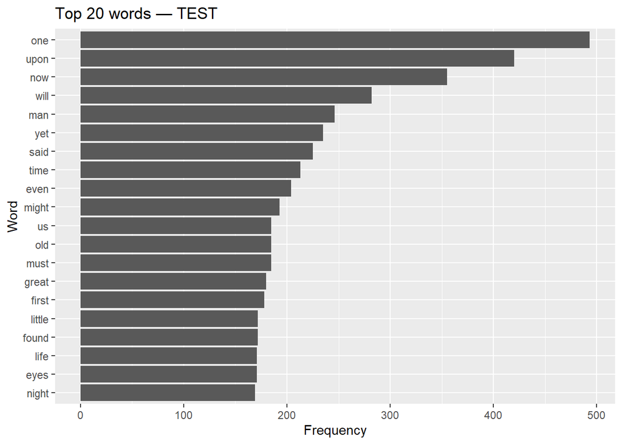

```r
# Top-20 barplot (test)
ggplot(t_counts_test %>% slice_max(freq, n = 20),
       aes(x = reorder(splitted, freq), y = freq)) +
  geom_col() +
  coord_flip() +
  labs(title = "Top 20 words — TEST", x = "Word", y = "Frequency")
```

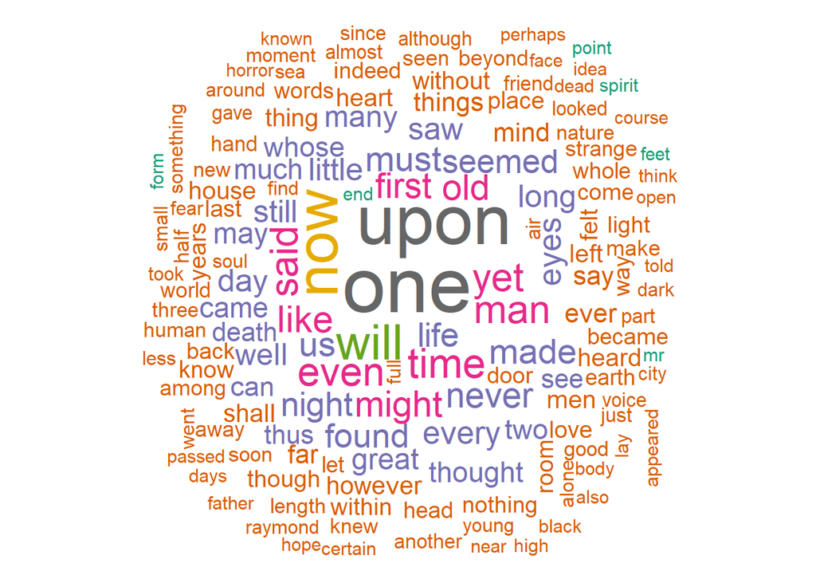

```r
# ----------  WORDCLOUDS ----------
set.seed(123)  # for reproducibility

# Wordcloud (train)
wordcloud(words = t_counts_train$splitted,
          freq  = t_counts_train$freq,
          min.freq = 20,
          max.words = 150,
          random.order = FALSE,
          colors = brewer.pal(8, "Dark2"))
```

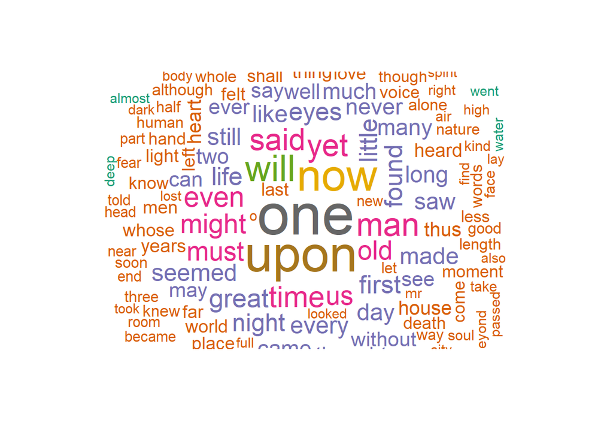

```r
# Wordcloud (test)
wordcloud(words = t_counts_test$splitted,
          freq  = t_counts_test$freq,
          min.freq = 20,
          max.words = 150,
          random.order = FALSE,
          colors = brewer.pal(8, "Dark2"))
```

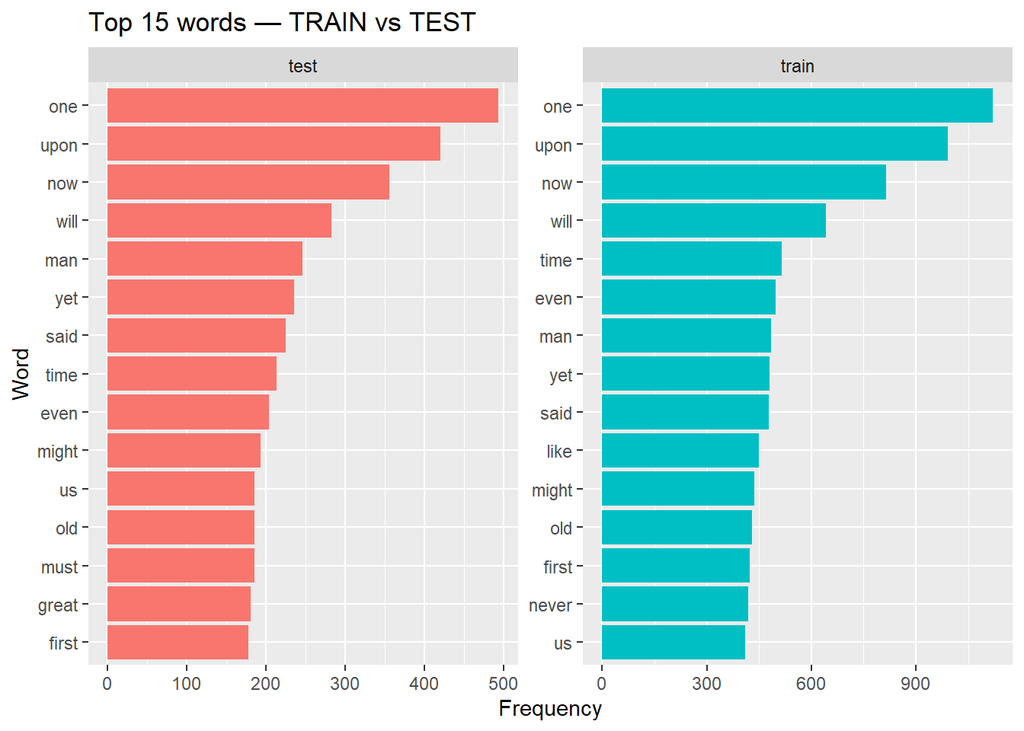

```r
# ---------- COMPARISON: TRAIN vs TEST (faceted barplots) ----------
both_counts <- bind_rows(
  t_counts_train %>% mutate(dataset = "train"),
  t_counts_test  %>% mutate(dataset = "test")
)

ggplot(both_counts %>% group_by(dataset) %>% slice_max(freq, n = 15),
       aes(x = reorder_within(splitted, freq, dataset), y = freq, fill = dataset)) +
  geom_col(show.legend = FALSE) +
  facet_wrap(~dataset, scales = "free") +
  coord_flip() +
  scale_x_reordered() +
  labs(title = "Top 15 words — TRAIN vs TEST",
       x = "Word", y = "Frequency")
```

## Classifier implementation

```r
naiveBayes <- setRefClass(
  "naiveBayes",

  fields = list(
    classes = "character",     # class labels
    vocab   = "character",     # all words in the bag-of-words
    log_pr  = "numeric",       # log P(c)
    log_lik = "matrix"         # log P(w|c)
  ),

  methods = list(
    fit = function(X, y) {
      # X: document-term matrix (rows = docs, cols = words, counts as values)
      # y: vector of class labels for each document

      classes <<- unique(y)
      vocab   <<- colnames(X)
      V <- length(vocab)

      # Priors: P(c) = fraction of docs in each class
      pr <- table(y) / length(y)
      log_pr <<- as.vector(log(pr[classes])) #changed
      names(log_pr) <<- classes

      # Word counts per class
      class_counts <- sapply(classes, function(cn) {
        rows <- which(y == cn)
        colSums(X[rows, , drop = FALSE])
      })
      class_counts <- as.matrix(class_counts)   # rows=vocab, cols=classes
      rownames(class_counts) <- vocab
      colnames(class_counts) <- classes

      # Laplace smoothing
      totals <- colSums(class_counts)
      lik <- sweep(class_counts + 1, 2, totals + V, "/")

      # Store log-likelihoods (rows=classes, cols=words)
      log_lik <<- t(log(lik))

      invisible(TRUE)
    },

    predict = function(message) {
      # message: named numeric vector with word counts (bag-of-words)
      scores <- sapply(1:length(classes), function(i) {
        log_pr[i] + sum(message * log_lik[i, ], na.rm = TRUE)
      })
      names(scores) <- classes
      names(which.max(scores))  # return predicted class
    },

    score = function(X_test, y_test) {
      # Predict all test docs
      preds <- apply(X_test, 1, function(row) .self$predict(row))
      acc <- mean(preds == y_test)
      cm <- table(True = y_test, Pred = preds)
      metrics <- calculate_multiclass_metrics(cm, classes)

      list(
        accuracy = acc,
        confusion_matrix = cm,
        metrics_per_class = metrics$per_class,
        macro_avg_metrics = metrics$macro_avg
      )
    }
  )
)

# Example usage:
# model = naiveBayes()
# model$fit(X_train, y_train)
# model$predict(X_train[1, ])
# model$score(X_test, y_test)
```

## Measure effectiveness of your classifier

- Note that accuracy is not always a good metric for your classifier. Look at precision and recall curves, F1 score metric.

  When evaluating the model, it’s important to understand the different types of classification results:
  - A *true positive* result is one where the model correctly predicts the positive class.
  - A *true negative* result is one where the model correctly predicts the negative class.
  - A *false positive* result is one where the model incorrectly predicts the positive class when it is actually negative.
  - A *false negative* result is one where the model incorrectly predicts the negative class when it is actually positive.

  Precision measures the proportion of true positive predictions among all positive predictions made by the model.

  $$Precision = \frac{TP}{TP+FP}$$

  Recall, on the other hand, measures the proportion of true positives identified out of all actual positive cases.

  $$Recall = \frac{TP}{TP+FN}$$

  F1 score is the harmonic mean of both precision and recall.

  $$F1 = \frac{2\times Precision \times Recall}{Precision + Recall}$$

  **See [this link](https://cohere.com/blog/classification-eval-metrics) to find more information about metrics.**

```r
calculate_multiclass_metrics <- function(cm, class_labels) {
  num_classes <- length(class_labels)

  # Initialize vectors to store per-class metrics
  precision_per_class <- numeric(num_classes)
  recall_per_class    <- numeric(num_classes)
  f1_per_class        <- numeric(num_classes)

  names(precision_per_class) <- class_labels
  names(recall_per_class)    <- class_labels
  names(f1_per_class)        <- class_labels

  for (i in seq_along(class_labels)) {
    # For a given class, consider it as the "positive" class
    current_class <- class_labels[i]

    TP <- cm[current_class, current_class]
    FP <- sum(cm[, current_class]) - TP
    FN <- sum(cm[current_class, ]) - TP
    TN <- sum(cm) - TP - FP - FN # Total - TP - FP - FN

    # Precision: TP / (TP + FP)
    precision <- ifelse((TP + FP) > 0, TP / (TP + FP), 0)
    # Recall: TP / (TP + FN)
    recall <- ifelse((TP + FN) > 0, TP / (TP + FN), 0)
    # F1 Score: 2 * (Precision * Recall) / (Precision + Recall)
    f1 <- ifelse((precision + recall) > 0, 2 * (precision * recall) / (precision + recall), 0)

    precision_per_class[current_class] <- precision
    recall_per_class[current_class]    <- recall
    f1_per_class[current_class]        <- f1
  }

  # Macro-average for overall metrics
  macro_precision <- mean(precision_per_class)
  macro_recall    <- mean(recall_per_class)
  macro_f1        <- mean(f1_per_class)

  list(
    per_class = data.frame(
      class = class_labels,
      precision = precision_per_class,
      recall = recall_per_class,
      f1_score = f1_per_class
    ),
    macro_avg = data.frame(
      metric = c("Precision", "Recall", "F1_Score"),
      value = c(macro_precision, macro_recall, macro_f1)
    )
  )
}


# Create a mapping from document ID to author for both train and test sets
train_labels <- train %>% distinct(id, author)
test_labels <- test %>% distinct(id, author)

# Create DTM for the training set using tidytext
dtm_train <- tidy_text_train %>%
  count(id, splitted) %>%
  cast_dtm(document = id, term = splitted, value = n)

dtm_test_original <- tidy_text_test %>%
  count(id, splitted) %>%
  cast_dtm(document = id, term = splitted, value = n)


train_vocab <- colnames(dtm_train)
dtm_test_aligned <- matrix(0,
                           nrow = nrow(dtm_test_original),
                           ncol = length(train_vocab),
                           dimnames = list(rownames(dtm_test_original), train_vocab))

common_vocab <- intersect(colnames(dtm_test_original), train_vocab)

# Fill the new aligned matrix with the counts from the original test matrix.
# We convert the subset of the original DTM to a standard matrix before assigning.
dtm_test_aligned[, common_vocab] <- as.matrix(dtm_test_original[, common_vocab])

X_train <- as.matrix(dtm_train)
X_test <- dtm_test_aligned

# Create the label vectors y_train and y_test
# Ensure the order of labels matches the order of rows in the matrices
y_train <- train_labels$author[match(rownames(X_train), train_labels$id)]
y_test <- test_labels$author[match(rownames(X_test), test_labels$id)]

# Clean up intermediate objects to save memory
rm(dtm_train, dtm_test_original, dtm_test_aligned)

# Instantiate and fit the model using the training data
model <- naiveBayes()
model$fit(X_train, y_train)

# Get the performance results on the test data
results <- model$score(X_test, y_test)

# Print all the calculated metrics in a structured way
cat("====================================================\n")
cat("      CLASSIFIER PERFORMANCE EVALUATION\n")
```

```
##       CLASSIFIER PERFORMANCE EVALUATION
```

```r
cat("====================================================\n\n")
# Print Overall Accuracy
cat(sprintf("Overall Accuracy: %.4f (%.2f%%)\n\n", results$accuracy, results$accuracy * 100))
```

```
## Overall Accuracy: 0.8348 (83.48%)
```

```r
cat("----------------------------------------------------\n")
# Print Confusion Matrix
cat("Confusion Matrix:\n")
```

```
## Confusion Matrix:
```

```r
print(results$confusion_matrix)
```

```
##                               Pred
## True                           Edgar Alan Poe HP Lovecraft
##   Edgar Alan Poe                         1950          148
##   HP Lovecraft                            177         1354
##   Mary Wollstonecraft Shelley             161           79
##                               Pred
## True                           Mary Wollstonecraft Shelley
##   Edgar Alan Poe                                        275
##   HP Lovecraft                                          130
##   Mary Wollstonecraft Shelley                          1599
```

```r
cat("\n----------------------------------------------------\n")
# Print Per-Class Metrics
cat("Metrics per Class (Precision, Recall, F1-Score):\n")
```

```
## Metrics per Class (Precision, Recall, F1-Score):
```

```r
print(results$metrics_per_class, row.names = FALSE)
```

```
##                         class precision    recall  f1_score
##  Mary Wollstonecraft Shelley  0.7979042 0.8694943 0.8321624
##                  HP Lovecraft 0.8564200 0.8151716 0.8352869
##                Edgar Alan Poe 0.8522727 0.8217446 0.8367303
```

```r
cat("\n----------------------------------------------------\n")
# Print Macro-Averaged Metrics
cat("Macro-Averaged Metrics:\n")
```

```
## Macro-Averaged Metrics:
```

```r
print(results$macro_avg_metrics, row.names = FALSE)
```

```
##     metric     value
##  Precision 0.8355323
##     Recall 0.8354702
##   F1_Score 0.8347265
```

```r
cat("\n====================================================\n\n")
```

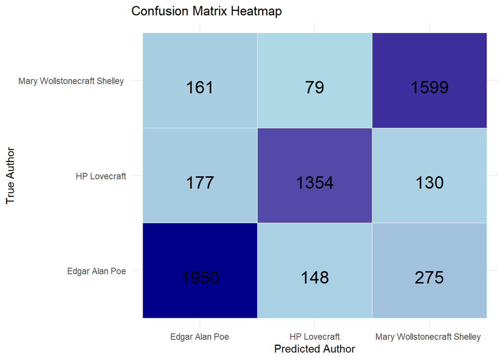

```r
# a) Visualize the Confusion Matrix as a Heatmap for better interpretation
cm_df <- as.data.frame(results$confusion_matrix)
ggplot(cm_df, aes(x = Pred, y = True, fill = Freq)) +
  geom_tile(color = "white") +
  geom_text(aes(label = Freq), vjust = 1, size = 6) +
  scale_fill_gradient(low = "lightblue", high = "darkblue") +
  labs(title = "Confusion Matrix Heatmap",
       x = "Predicted Author",
       y = "True Author") +
  theme_minimal() +
  theme(legend.position = "none")
```

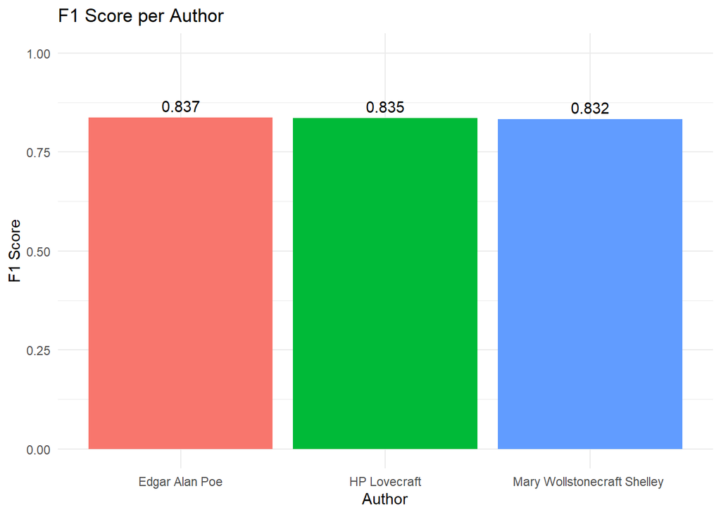

```r
# b) Visualize Per-Class F1 Scores for easy comparison
ggplot(results$metrics_per_class, aes(x = reorder(class, -f1_score), y = f1_score, fill = class)) +
  geom_bar(stat = "identity", show.legend = FALSE) +
  geom_text(aes(label = sprintf("%.3f", f1_score)), vjust = -0.5) +
  ylim(0, 1) +
  labs(title = "F1 Score per Author",
       x = "Author",
       y = "F1 Score") +
  theme_minimal()
```

```r
# Get predictions for the entire test set
predictions <- apply(X_test, 1, function(row) model$predict(row))

# Combine results into a single data frame
failure_df <- data.frame(
  id = rownames(X_test),
  true_author = y_test,
  predicted_author = predictions,
  stringsAsFactors = FALSE
)

# Find the cases where the model made a mistake
mistakes <- failure_df %>%
  filter(true_author != predicted_author) %>%
  # Join with the original test data to get the text
  left_join(test, by = "id") %>%
  select(id, text, true_author, predicted_author)

cat("\n====================================================\n")
cat("             ANALYSIS OF FAILURE CASES\n")
```

```
##              ANALYSIS OF FAILURE CASES
```

```r
cat("====================================================\n\n")
cat(sprintf("The classifier made %d mistakes out of %d predictions.\n", nrow(mistakes), length(y_test)))
```

```
## The classifier made 970 mistakes out of 5873 predictions.
```

```r
cat("Here are a few examples of incorrect classifications:\n\n")
```

```
## Here are a few examples of incorrect classifications:
```

```r
# Display the first 5 failure cases (or fewer if there are not that many)
if (nrow(mistakes) > 0) {
  for (i in 1:min(5, nrow(mistakes))) {
    cat(sprintf("--- Example %d ---\n", i))
    cat(sprintf("Text: \"%s...\"\n", substr(mistakes$text[i], 1, 100)))
    cat(sprintf("True Author:      %s\n", mistakes$true_author[i]))
    cat(sprintf("Predicted Author: %s\n\n", mistakes$predicted_author[i]))
  }
} else {
  cat("Wow! There were no mistakes on the test set. Perfect classification!\n")
}
```

```
## --- Example 1 ---
## Text: "Books like Ignatius Donnelly's chimerical account of Atlantis he absorbed with zest, and a dozen obs..."
## True Author:      HP Lovecraft
## Predicted Author: Mary Wollstonecraft Shelley
##
## --- Example 2 ---
## Text: "Tidings of an armed and regular opposition recalled them to a sort of order...."
## True Author:      Mary Wollstonecraft Shelley
## Predicted Author: HP Lovecraft
##
## --- Example 3 ---
## Text: "Of the dungeons there had been strange things narrated fables I had always deemed them but yet stran..."
## True Author:      Edgar Alan Poe
## Predicted Author: HP Lovecraft
##
## --- Example 4 ---
## Text: "He hurried in, and witnessed the termination of my impassioned harangue...."
## True Author:      Mary Wollstonecraft Shelley
## Predicted Author: Edgar Alan Poe
##
## --- Example 5 ---
## Text: "Sewers came, but they passed by it...."
## True Author:      HP Lovecraft
## Predicted Author: Mary Wollstonecraft Shelley
```

- Visualize them.
- Show failure cases.

Conclusions

Summarize your work by explaining in a few sentences the points listed below.

- Describe the method implemented in general. Show what are mathematical foundations you are basing your solution on.
- List pros and cons of the method. This should include the limitations of your method, all the assumption you make about the nature of your data etc.
- Explain why accuracy is not a good choice for the base metrics for classification tasks. Why F1 score is always preferable?

## Conclusions

**Method and Mathematical Foundations**

The core of this project was the implementation of a **Multinomial Naive Bayes classifier**, a probabilistic algorithm well-suited for text classification. The model is founded on **Bayes’ Theorem**:

$$\mathsf{P}(\mathrm{class}\mid
\mathrm{observation})=\frac{\mathsf{P}(\mathrm{observation}\mid\mathrm{class})\mathsf{P}(\mathrm{class})}{\mathsf{P}(\mathrm{observation})}$$

**Pros and Cons of the Method**

The Naive Bayes method has several distinct advantages and limitations.

- **Pros:** The classifier is computationally efficient and fast, requiring a relatively small training set to estimate its parameters. Its underlying logic is simple to understand and implement. Despite its simplistic assumptions, it often performs surprisingly well, especially for text-based tasks.
- **Cons:** The primary limitation is the **independence assumption**, as words in a language are rarely independent. This can lead to suboptimal results if features are strongly correlated. Another issue is the **zero-frequency problem**, where a word in the test set has not appeared in the training data for a class. This was mitigated in our implementation by using Laplace smoothing.

**Evaluation Metrics: Accuracy vs. F1 Score**

While **accuracy** is an intuitive metric, it can be misleading for classification tasks, especially with an imbalanced class distribution. A model could achieve high accuracy by simply predicting the majority class every time, rendering it useless for identifying minority classes.

The **F1 score** is a more robust metric because it balances **precision** and **recall** by calculating their harmonic mean.

- **Precision** measures the proportion of true positive predictions among all positive predictions made (`TP / (TP + FP)`). It quantifies the quality of positive predictions.
- **Recall** measures the proportion of true positives that were correctly identified out of all actual positives (`TP / (TP + FN)`). It quantifies the completeness of positive predictions.